# Within-Subject Comparisons

Let’s compare the time variables using only participants with both episodes and controls.

`r`r library(tidyverse, quietly = T) library(caret, quietly = T) library(DMwR, quietly = T) library(ROSE, quietly = T) library(viridis, quietly = T) library(DAAG, quietly = T) head(features_output)

|  | ID | when | Event | Stress | Y | threshold | winds | index | SDNN | SDANN | SDNNIDX | pNN50 | SDSD | rMSSD | IRRR | MADRR | TINN | HRVi | Avg_niHR | Start_niHR | End_niHR | Avg_HR | HF_1 | HF_2 | HF_3 | HF_4 | HF_5 | HF_6 | LF_1 | … |
| --- | --- | --- | --- | --- | --- | --- | --- | --- | --- | --- | --- | --- | --- | --- | --- | --- | --- | --- | --- | --- | --- | --- | --- | --- | --- | --- | --- | --- | --- | --- |
| 1 | 200 | 2016-12-22 23:29:35 | 2016-12-22 23:29:35 | 2 | Control | 250 | 2 | 1 | 79.16171 | NA | NA | NA | NA | NA | NA | NA | NA | NA | 65.75336 | 95.99557 | 63.99707 | 64.86980 | NaN | NaN | NaN | 343.3118 | NaN | 686.5933 | NaN | … |
| 2 | 200 | 2016-12-23 01:28:47 | 2016-12-23 01:28:47 | 1 | Control | 250 | 2 | 2 | NA | NA | NA | NA | NA | NA | NA | NA | NA | NA | NA | NA | NA | NA | NA | NA | NA | NA | NA | NA | NA | … |
| 3 | 200 | 2016-12-23 13:44:13 | 2016-12-23 13:44:13 | 2 | Control | 250 | 2 | 3 | 82.15854 | NA | NA | NA | NA | NA | NA | NA | NA | NA | 74.87121 | 78.36376 | 78.36376 | 72.21005 | NaN | NaN | NaN | NaN | NaN | NaN | NaN | … |
| 4 | 200 | 2016-12-23 15:27:36 | 2016-12-23 15:27:36 | 1 | Control | 250 | 2 | 4 | 129.20003 | NA | NA | NA | NA | NA | NA | NA | NA | NA | 84.13310 | 73.84280 | 59.07425 | 77.09793 | NaN | 165.3426 | NaN | NaN | NaN | NaN | NaN | … |
| 5 | 200 | 2016-12-23 18:17:50 | 2016-12-23 18:17:50 | 1 | Control | 250 | 2 | 5 | 115.47438 | NA | NA | NA | NA | NA | NA | NA | NA | NA | 66.34141 | 153.59297 | 56.46804 | 64.65425 | NaN | NaN | 522.9991 | 608.8710 | 675.2361 | 948.9223 | NaN | … |
| 6 | 200 | 2016-12-23 20:19:34 | 2016-12-23 20:19:34 | 3 | Control | 250 | 2 | 6 | 157.67355 | NA | NA | NA | NA | NA | NA | NA | NA | NA | 73.51861 | 85.32946 | 61.93268 | 69.43448 | NaN | NaN | NaN | NaN | NaN | NaN | NaN | … |

How many cases are there to use?

`r`r features_output%>% filter(!(Stress > 4 & Y == ))%>% #filter high stress select(ID, Y, SDNN:HRVi)%>% filter(complete.cases(.))%>% group_by(ID, Y)%>% count()

| ID | Y | n |
| --- | --- | --- |
| 201 | Control | 3 |
| 201 | Episode | 2 |
| 202 | Control | 1 |
| 202 | Episode | 1 |
| 207 | Control | 9 |
| 207 | Episode | 7 |
| 212 | Control | 3 |
| 213 | Control | 2 |
| 214 | Control | 5 |
| 214 | Episode | 1 |

[output cut: 17 more lines]

`r`r #save participants who qualify pp = c(201, 202, 207, 214, 215, 217, 218, 219, 220, 222)

# Within Participant Comparisons

Here we compare within-participant if episodes have higher time-scale variables than controls, for each participant.

A plot for clarity

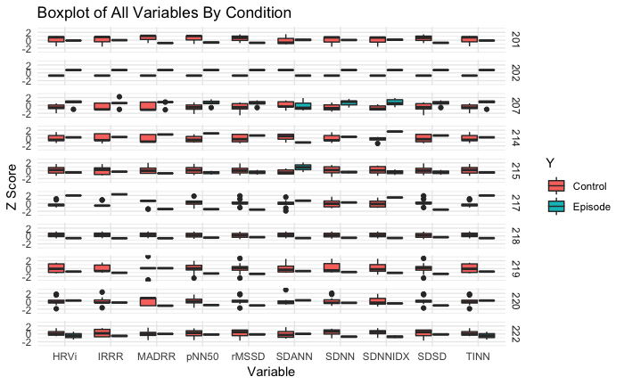

Single lines indicate that there’s only one reading for that participant’s variable. This is in a lot of cases, unfortunately, as you can see from the previous table. I’d only feel comfortable running the permutation T with 207, who has in total 9 controls and 7 episodes. But we can still attempt the t-tests regardless:

`r`r simple_scale = function(vec){ vec%>% scale()%>% as.numeric()%>% return() } features_output%>% filter(!(Stress > 4 & Y == ))%>% #filter high stress #filter(ID == 207)%>% filter(ID %in% pp)%>% select(ID, Y, SDNN:HRVi)%>% filter(complete.cases(.))%>% group_by(ID)%>% mutate_at(.vars = vars(SDNN:HRVi), funs(simple_scale))%>% #z score transform select(Y:HRVi)%>% summarise_at(funs(twotPermutation(.[Y == ], .[Y != ], plotit = F)), .vars = vars(SDNN:HRVi))

| ID | SDNN | SDANN | SDNNIDX | pNN50 | SDSD | rMSSD | IRRR | MADRR | TINN | HRVi |
| --- | --- | --- | --- | --- | --- | --- | --- | --- | --- | --- |
| 201 | 1.0000 | 1.000 | 1.000 | 0.402 | 0.3750 | 0.396 | 1.0000 | 0.4040 | 1.000 | 1.0000 |
| 202 | 1.0000 | 1.000 | 1.000 | 1.000 | 1.0000 | 1.000 | 1.0000 | 1.0000 | 1.000 | 1.0000 |
| 207 | 0.0165 | 0.712 | 0.005 | 0.013 | 0.0345 | 0.026 | 0.0145 | 0.0105 | 0.014 | 0.0055 |
| 214 | 1.0000 | 0.342 | 0.156 | 0.160 | 0.8420 | 0.830 | 1.0000 | 0.3400 | 1.000 | 1.0000 |
| 215 | 0.6880 | 0.150 | 0.606 | 0.521 | 0.5900 | 0.564 | 0.6790 | 0.4700 | 0.534 | 0.5350 |
| 217 | 0.7780 | 0.505 | 0.100 | 0.184 | 0.2130 | 0.194 | 0.0930 | 0.0985 | 0.112 | 0.1100 |
| 218 | 1.0000 | 1.000 | 1.000 | 1.000 | 1.0000 | 1.000 | 0.6660 | 1.0000 | 1.000 | 1.0000 |
| 219 | 0.4650 | 0.684 | 0.347 | 0.170 | 0.1700 | 0.174 | 0.4680 | 1.0000 | 0.725 | 0.7240 |
| 220 | 0.7620 | 0.749 | 0.756 | 0.324 | 0.3440 | 0.344 | 0.7500 | 0.3240 | 0.717 | 0.7430 |
| 222 | 0.3320 | 1.000 | 0.254 | 0.794 | 0.9400 | 0.944 | 0.5360 | 0.6780 | 0.464 | 0.4640 |

The above table shows the $p$ value for each Episode vs Control hypothesis test that the variable is significantly different. Each row is a participant, and each column is a variable to be tested for condition. The participants with any significant $p$ values are shown below:

`r`r features_output%>% filter(!(Stress > 4 & Y == ))%>% #filter high stress #filter(ID == 207)%>% filter(ID %in% pp)%>% select(ID, Y, SDNN:HRVi)%>% filter(complete.cases(.))%>% group_by(ID)%>% mutate_at(.vars = vars(SDNN:HRVi), funs(simple_scale))%>% #z score transform select(Y:HRVi)%>% summarise_at(funs(twotPermutation(.[Y == ], .[Y != ], plotit = F)), .vars = vars(SDNN:HRVi))%>% filter_at(vars(SDNN:HRVi), any_vars(. < 0.05))

| ID | SDNN | SDANN | SDNNIDX | pNN50 | SDSD | rMSSD | IRRR | MADRR | TINN | HRVi |
| --- | --- | --- | --- | --- | --- | --- | --- | --- | --- | --- |
| 207 | 0.017 | 0.724 | 0.0015 | 0.011 | 0.032 | 0.031 | 0.0165 | 0.011 | 0.0055 | 0.0145 |

As expected, participant 207 is the only one who would have any significantly different conditions, for all but SDANN.

# Predicting Condition

We use simple over- and under-sampling as well as ROSE and SMOTE to deal with the class imbalance problem. We also only use participants who have both controls and episodes.

| Class | SDNN | SDANN | SDNNIDX | pNN50 | SDSD | rMSSD | IRRR | MADRR | TINN | HRVi |
| --- | --- | --- | --- | --- | --- | --- | --- | --- | --- | --- |
| Control | -0.256200442 | -0.96616825 | 0.0261752097 | 0.617146922 | 0.5286578761 | 0.529498182 | 0.51069721 | 4.907187e-01 | -0.33322975 | -0.33322975 |
| Control | 0.873699259 | -0.71698468 | 0.9319556764 | 0.847987896 | 0.9282474024 | 0.928707273 | 1.43332876 | 4.905989e-01 | 1.51906027 | 1.51906027 |
| Control | -0.317714741 | -0.73832760 | -0.0904701574 | 0.501583662 | 0.9203043312 | 0.922021075 | -0.41187802 | 4.905989e-01 | -0.58559865 | -0.58559865 |
| Control | 0.551339394 | 1.87380588 | 0.4133114659 | -0.613249543 | -0.8458864474 | -0.845521617 | 0.51076760 | 4.905989e-01 | 0.48966284 | 0.48966284 |
| Control | -2.103205685 | -0.51970605 | -1.8195421521 | -1.320732966 | -1.3707968367 | -1.371186757 | -2.25708480 | -1.471989e+00 | -1.72311235 | -1.72311235 |
| Control | -0.122529771 | 2.25068657 | -0.2809651987 | -0.319664846 | -0.3992242103 | -0.397618119 | 0.51071129 | 4.905989e-01 | 0.73927034 | 0.73927034 |
| Control | -0.200440801 | -0.73230413 | 0.3427815015 | 0.909403150 | 0.9523013680 | 0.951095206 | 0.51069721 | 4.907187e-01 | -0.28226610 | -0.28226610 |
| Episode | 1.552336740 | -0.65012526 | 2.2967439266 | 1.177977267 | 0.9440169767 | 0.944844828 | 1.43341322 | 4.907486e-01 | 1.88823670 | 1.88823670 |
| Episode | -0.298707960 | 0.58743496 | -0.3317017287 | 0.093729687 | -0.2559800360 | -0.259278199 | -0.41182171 | 4.905989e-01 | -0.21631183 | -0.21631183 |
| Episode | -0.727472068 | -0.08594533 | -0.7917099719 | -1.240557741 | -1.3675066593 | -1.368110840 | -0.41187802 | -1.471959e+00 | -0.31888878 | -0.31888878 |

[output cut: 138 more lines]

## Logistic Regression/GLM

Fitting a glm and inspecting the model fit:

`r`r #empty vectors for sampling methods glmFitSummaries = vector() glmModels = vector() #loop through the different samples and fit the model for each #store results in empty vectors for(s in 1:length(samples)){ print(names(samples)[[s]])

glmModels[[names(samples)[s]]] = train(Class ~., method = , family=binomial, data=samples[[s]])

#collect variable significance metrics glmFitSummaries[[names(samples)[s]]] = summary(glmModels[[names(samples)[s]]]$finalModel)%>% .$coefficients%>% data.frame()%>% as.tibble()%>% rownames_to_column(var = )%>% rename(P_Value = Pr…z.., Z_Value = z.value, Std_Error = Std..Error)%>% mutate(Significant = ifelse(P_Value < 0.05, , Significant), Sampling = names(samples)[[s]]) }

```
[1] \None\
[1] \DownSample\
[1] \UpSample\
[1] \SMOTE\
[1] \ROSE\
```

`r`r #print the GLM variable estimates and significance for each model do.call(rbind, glmFitSummaries)%>% select(Sampling, Variable, Significant, everything())

|  | Sampling | Variable | Significant | Estimate | Std_Error | Z_Value | P_Value |
| --- | --- | --- | --- | --- | --- | --- | --- |
| 1 | None | (Intercept) | Significant | -1.583126e+00 | 0.3657326 | -4.32864327 | 1.500307e-05 |
| 2 | None | SDNN | Not Significant | -4.822718e-01 | 0.8572982 | -0.56254851 | 5.737424e-01 |
| 3 | None | SDANN | Not Significant | -7.204263e-01 | 0.4135498 | -1.74205469 | 8.149887e-02 |
| 4 | None | SDNNIDX | Not Significant | 8.999230e-01 | 0.8136047 | 1.10609367 | 2.686860e-01 |
| 5 | None | pNN50 | Not Significant | 1.019281e-01 | 1.5676896 | 0.06501805 | 9.481596e-01 |
| 6 | None | SDSD | Not Significant | 4.493050e+02 | 922.1234715 | 0.48725033 | 6.260809e-01 |
| 7 | None | rMSSD | Not Significant | -4.504482e+02 | 922.3408689 | -0.48837501 | 6.252842e-01 |
| 8 | None | IRRR | Not Significant | -2.645060e-01 | 0.8044097 | -0.32882002 | 7.422917e-01 |
| 9 | None | MADRR | Not Significant | 4.332078e-01 | 0.6044962 | 0.71664267 | 4.735946e-01 |
| 10 | None | TINN | Not Significant | 1.072407e+00 | 0.8674378 | 1.23629300 | 2.163497e-01 |

[output cut: 41 more lines]

Upsampling produced the highest number of significant predictors.

Evaluating prediction:

`r`r #empy vectors for results glmResults = vector() glmPredictions = vector() #loop through the different samples and predict test cases #store results in empty vectors for(s in 1:length(samples)){ print(names(samples)[[s]])

pred = predict( glmModels[[names(samples)[s]]], newdata = mydat[-train,], type = )%>% data.frame(pred = ., obs = mydat$Class[-train])

glmPredictions[[names(samples)[s]]] = pred

glmResults[[names(samples)[s]]] = confusionMatrix(pred$pred, pred$obs, positive = ) }

```
[1] \None\
prediction from a rank-deficient fit may be misleading
[1] \DownSample\
prediction from a rank-deficient fit may be misleading
[1] \UpSample\
prediction from a rank-deficient fit may be misleading
[1] \SMOTE\
prediction from a rank-deficient fit may be misleading
[1] \ROSE\
```

`r`r #data frame for compiling results comparisons = data.frame() #loop through each sampling method’s results and compile for(x in 1:length(glmResults)){

comparisons = glmResults[[names(samples)[x]]]$byClass%>% data.frame(Value = .)%>% rownames_to_column()%>% rename(Variable = rowname)%>% mutate(Sampling = names(samples)[x])%>% select(Sampling, everything())%>% rbind(comparisons, .) } #plot comparisons%>% ggplot(aes(x = Variable, y = Value))+ geom_point(aes(color = Sampling, shape = Sampling), alpha = 0.7, size = 5)+ theme_minimal()+ labs(title = : Classification Metrics by Sampling Method, x = )+ coord_flip()+ theme(text = element_text(size = 15))+ scale_color_viridis(discrete = TRUE)

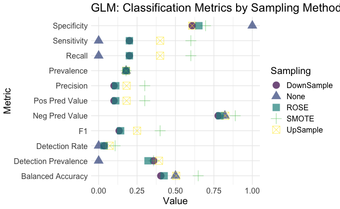

SMOTE resampling produced the highest accuracy, precision, and sensitivity.

## Results

`r`r lapply(glmPredictions, table)

```
$None
         obs
pred      Control Episode
  Control      23       5
  Episode       0       0

$DownSample
         obs
pred      Control Episode
  Control      14       4
  Episode       9       1

$UpSample
         obs
pred      Control Episode
  Control      14       3
  Episode       9       2

$SMOTE
         obs
pred      Control Episode
  Control      16       2
  Episode       7       3

$ROSE
         obs
pred      Control Episode
  Control      15       4
  Episode       8       1
```

`r`r do.call(rbind, glmPredictions)%>% rownames_to_column()%>% rename(S = rowname)%>% separate(S, c(, ), sep = \.)%>% select(-xx)%>% group_by(Sampling)%>% summarise(Overall_Accuracy = sum(pred == obs)/n())%>% arrange(desc(Overall_Accuracy)) r final_glm = comparisons%>% filter(Sampling == )%>% arrange(Variable)%>% mutate(Model = )%>% select(Model, everything()) final_glm

| Sampling | Overall_Accuracy |
| --- | --- |
| None | 0.8214286 |
| SMOTE | 0.6785714 |
| ROSE | 0.5714286 |
| UpSample | 0.5714286 |
| DownSample | 0.5357143 |

| Model | Sampling | Variable | Value |
| --- | --- | --- | --- |
| LogisticRegression | SMOTE | Balanced Accuracy | 0.6478261 |
| LogisticRegression | SMOTE | Detection Prevalence | 0.3571429 |
| LogisticRegression | SMOTE | Detection Rate | 0.1071429 |
| LogisticRegression | SMOTE | F1 | 0.4000000 |
| LogisticRegression | SMOTE | Neg Pred Value | 0.8888889 |
| LogisticRegression | SMOTE | Pos Pred Value | 0.3000000 |
| LogisticRegression | SMOTE | Precision | 0.3000000 |
| LogisticRegression | SMOTE | Prevalence | 0.1785714 |
| LogisticRegression | SMOTE | Recall | 0.6000000 |
| LogisticRegression | SMOTE | Sensitivity | 0.6000000 |

[output cut: 1 more lines]

## RandomForest

Fitting a random forest model for each resampling method:

```
[1] \None\
There were missing values in resampled performance measures.
[1] \DownSample\
There were missing values in resampled performance measures.
[1] \UpSample\
There were missing values in resampled performance measures.
[1] \SMOTE\
There were missing values in resampled performance measures.
[1] \ROSE\
There were missing values in resampled performance measures.
```

`r`r # plotting solution found here: # https://github.com/dgrtwo/drlib/blob/master/R/reorder_within.R # Much appreciated @drlib reorder_within <- function(x, by, within, fun = mean, sep = _**, …) { new_x <- paste(x, within, sep = sep) stats::reorder(new_x, by, FUN = fun) } scale_x_reordered <- function(…, sep = _**) { reg <- paste0(sep, .+$\) ggplot2::scale_x_discrete(labels = function(x) gsub(reg, \\, x), ...) } scale_y_reordered <- function(..., sep = \___\) { reg <- paste0(sep, \.+$) ggplot2::scale_y_discrete(labels = function(x) gsub(reg, \, x), …) } do.call(rbind, rfFitSummaries)%>% mutate_if(is.character, as.factor)%>% ggplot(., aes(x = reorder_within(Variable, MeanDecreaseGini, Sampling), y = MeanDecreaseGini, fill = Variable))+ geom_bar(stat = , show.legend = FALSE)+ scale_x_reordered()+ facet_wrap(~Sampling, scales = )+ coord_flip()+ labs(x=, title = Importance Per Sampling Method, subtitle = $Lower Values Indicate More Importance in Making Stronger Final Predictions)$+ theme_minimal()+ scale_fill_viridis(discrete=TRUE)

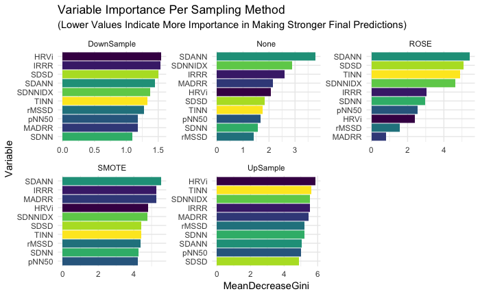

Using random forest the most important variable for prediction varies with the resampling approach, so it’s hard to tell what’s being said here.

Evaluating prediction:

`r`r #empy vectors for results rfResults = vector() rfPredictions = vector() #loop through the different samples and predict test cases #store results in empty vectors for(s in 1:length(samples)){ print(names(samples)[[s]])

rfPredictions[[names(samples)[s]]] = predict(rfModels[[names(samples)[s]]],newdata=mydat[-train,])%>% tibble(pred = ., obs = mydat[-train,]$Class)

rfResults[[names(samples)[s]]] = confusionMatrix(pred$pred, pred$obs, positive = ) }

```
[1] \None\
[1] \DownSample\
[1] \UpSample\
[1] \SMOTE\
[1] \ROSE\
```

`r`r #data frame for compiling results comparisons = data.frame() #loop through each sampling method’s results and compile for(x in 1:length(glmResults)){

comparisons = rfResults[[names(samples)[x]]]$byClass%>% data.frame(Value = .)%>% rownames_to_column()%>% rename(Variable = rowname)%>% mutate(Sampling = names(samples)[x])%>% select(Sampling, everything())%>% rbind(comparisons, .) } #plot comparisons%>% ggplot(aes(x = Variable, y = Value))+ geom_point(aes(color = Sampling, shape = Sampling), alpha = 0.7, size = 5)+ theme_minimal()+ labs(title = Forest: Classification Metrics by Sampling Method, x = )+ coord_flip()+ theme(text = element_text(size = 15))+ scale_color_viridis(discrete = TRUE)

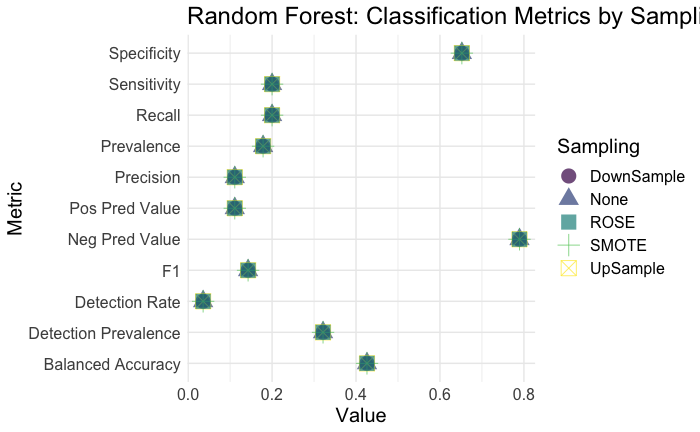

## Results

`r`r lapply(rfPredictions, table)

```
$None
         obs
pred      Control Episode
  Control      21       5
  Episode       2       0

$DownSample
         obs
pred      Control Episode
  Control      16       4
  Episode       7       1

$UpSample
         obs
pred      Control Episode
  Control      22       5
  Episode       1       0

$SMOTE
         obs
pred      Control Episode
  Control      16       3
  Episode       7       2

$ROSE
         obs
pred      Control Episode
  Control      16       5
  Episode       7       0
```

`r`r do.call(rbind, rfPredictions)%>% rownames_to_column()%>% rename(S = rowname)%>% separate(S, c(, ), sep = \.)%>% select(-xx)%>% group_by(Sampling)%>% summarise(Overall_Accuracy = sum(pred == obs)/n())%>% arrange(desc(Overall_Accuracy)) r final_RF = comparisons%>% filter(Sampling == )%>% arrange(Variable)%>% mutate(Model = )%>% select(Model, everything()) final_RF

| Sampling | Overall_Accuracy |
| --- | --- |
| UpSample | 0.7857143 |
| None | 0.7500000 |
| SMOTE | 0.6428571 |
| DownSample | 0.6071429 |
| ROSE | 0.5714286 |

| Model | Sampling | Variable | Value |
| --- | --- | --- | --- |
| RandomForest | UpSample | Balanced Accuracy | 0.42608696 |
| RandomForest | UpSample | Detection Prevalence | 0.32142857 |
| RandomForest | UpSample | Detection Rate | 0.03571429 |
| RandomForest | UpSample | F1 | 0.14285714 |
| RandomForest | UpSample | Neg Pred Value | 0.78947368 |
| RandomForest | UpSample | Pos Pred Value | 0.11111111 |
| RandomForest | UpSample | Precision | 0.11111111 |
| RandomForest | UpSample | Prevalence | 0.17857143 |
| RandomForest | UpSample | Recall | 0.20000000 |
| RandomForest | UpSample | Sensitivity | 0.20000000 |

[output cut: 1 more lines]

Upsampling has the best overall accuracy for prediction with this model.

## Support Vector Machine

Fitting and inspecting the model:

`r`r svmFitSummaries

```
$None

Call:
svm.default(x = as.matrix(x), y = y, kernel = \linear\, cost = param$cost,
    probability = classProbs)


Parameters:
   SVM-Type:  C-classification
 SVM-Kernel:  linear
       cost:  0.03633674
      gamma:  0.1

Number of Support Vectors:  32

 ( 18 14 )


Number of Classes:  2

Levels:
 Control Episode




$DownSample

Call:
svm.default(x = as.matrix(x), y = y, kernel = \linear\, cost = param$cost,
    probability = classProbs)


Parameters:
   SVM-Type:  C-classification
 SVM-Kernel:  linear
       cost:  0.1573957
      gamma:  0.1

Number of Support Vectors:  27
```

[output cut: 71 more lines]

```
Parameters:
   SVM-Type:  C-classification
 SVM-Kernel:  linear
       cost:  0.4266217
      gamma:  0.1

Number of Support Vectors:  39

 ( 20 19 )


Number of Classes:  2

Levels:
 Control Episode
```

Not much to interpret from SVM summaries.

Evaluating prediction:

`r`r #empy vectors for results svmResults = vector() svmPredictions = vector() #loop through the different samples and predict test cases #store results in empty vectors for(s in 1:length(samples)){ print(names(samples)[[s]])

svmPredictions[[names(samples)[s]]] = predict(svmModels[[names(samples)[s]]],newdata=mydat[-train,])%>% tibble(pred = ., obs = mydat[-train,]$Class)

svmResults[[names(samples)[s]]] = confusionMatrix(pred$pred, pred$obs, positive = ) }

```
[1] \None\
[1] \DownSample\
[1] \UpSample\
[1] \SMOTE\
[1] \ROSE\
```

`r`r #data frame for compiling results comparisons = data.frame() #loop through each sampling method’s results and compile for(x in 1:length(svmResults)){

comparisons = svmResults[[names(samples)[x]]]$byClass%>% data.frame(Value = .)%>% rownames_to_column()%>% rename(Variable = rowname)%>% mutate(Sampling = names(samples)[x])%>% select(Sampling, everything())%>% rbind(comparisons, .) } #plot comparisons%>% ggplot(aes(x = Variable, y = Value))+ geom_point(aes(color = Sampling, shape = Sampling), alpha = 0.7, size = 5)+ theme_minimal()+ labs(title = : Classification Metrics by Sampling Method, x = )+ coord_flip()+ theme(text = element_text(size = 15))+ scale_color_viridis(discrete = TRUE)

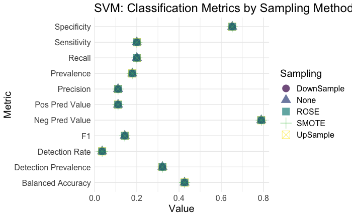

## Results

`r`r lapply(svmPredictions, table)

```
$None
         obs
pred      Control Episode
  Control      23       5
  Episode       0       0

$DownSample
         obs
pred      Control Episode
  Control      17       4
  Episode       6       1

$UpSample
         obs
pred      Control Episode
  Control      13       3
  Episode      10       2

$SMOTE
         obs
pred      Control Episode
  Control      13       5
  Episode      10       0

$ROSE
         obs
pred      Control Episode
  Control      15       5
  Episode       8       0
```

`r`r do.call(rbind, svmPredictions)%>% rownames_to_column()%>% rename(S = rowname)%>% separate(S, c(, ), sep = \.)%>% select(-xx)%>% group_by(Sampling)%>% summarise(Overall_Accuracy = sum(pred == obs)/n())%>% arrange(desc(Overall_Accuracy)) r final_svm = comparisons%>% filter(Sampling == )%>% arrange(Variable)%>% mutate(Model = )%>% select(Model, everything()) final_svm

| Sampling | Overall_Accuracy |
| --- | --- |
| None | 0.8214286 |
| DownSample | 0.6428571 |
| ROSE | 0.5357143 |
| UpSample | 0.5357143 |
| SMOTE | 0.4642857 |

| Model | Sampling | Variable | Value |
| --- | --- | --- | --- |
| SVM | None | Balanced Accuracy | 0.42608696 |
| SVM | None | Detection Prevalence | 0.32142857 |
| SVM | None | Detection Rate | 0.03571429 |
| SVM | None | F1 | 0.14285714 |
| SVM | None | Neg Pred Value | 0.78947368 |
| SVM | None | Pos Pred Value | 0.11111111 |
| SVM | None | Precision | 0.11111111 |
| SVM | None | Prevalence | 0.17857143 |
| SVM | None | Recall | 0.20000000 |
| SVM | None | Sensitivity | 0.20000000 |

[output cut: 1 more lines]

Still not much improvement here.

## NeuralNet

Fitting and inspecing the model:

`r`r nnetFitSummaries

```
$None
a 10-2-1 network with 25 weights
inputs: SDNN SDANN SDNNIDX pNN50 SDSD rMSSD IRRR MADRR TINN HRVi
output(s): .outcome
options were - entropy fitting  decay=0.2062722

$DownSample
a 10-20-1 network with 241 weights
inputs: SDNN SDANN SDNNIDX pNN50 SDSD rMSSD IRRR MADRR TINN HRVi
output(s): .outcome
options were - entropy fitting  decay=0.0002704312

$UpSample
a 10-14-1 network with 169 weights
inputs: SDNN SDANN SDNNIDX pNN50 SDSD rMSSD IRRR MADRR TINN HRVi
output(s): .outcome
options were - entropy fitting  decay=0.06020321

$SMOTE
a 10-14-1 network with 169 weights
inputs: SDNN SDANN SDNNIDX pNN50 SDSD rMSSD IRRR MADRR TINN HRVi
output(s): .outcome
options were - entropy fitting  decay=5.294455e-05

$ROSE
a 10-9-1 network with 109 weights
inputs: SDNN SDANN SDNNIDX pNN50 SDSD rMSSD IRRR MADRR TINN HRVi
output(s): .outcome
options were - entropy fitting  decay=0.001101804
```

Evaluating prediction:

`r`r #empy vectors for results nnetResults = vector() nnetPredictions = vector() #loop through the different samples and predict test cases #store results in empty vectors for(s in 1:length(samples)){ print(names(samples)[[s]])

nnetPredictions[[names(samples)[s]]] = predict(nnetModels[[names(samples)[s]]],newdata=mydat[-train,])%>% tibble(pred = ., obs = mydat[-train,]$Class)

nnetResults[[names(samples)[s]]] = confusionMatrix(pred$pred, pred$obs, positive = ) }

```
[1] \None\
[1] \DownSample\
[1] \UpSample\
[1] \SMOTE\
[1] \ROSE\
```

`r`r #data frame for compiling results comparisons = data.frame() #loop through each sampling method’s results and compile for(x in 1:length(nnetResults)){

comparisons = nnetResults[[names(samples)[x]]]$byClass%>% data.frame(Value = .)%>% rownames_to_column()%>% rename(Variable = rowname)%>% mutate(Sampling = names(samples)[x])%>% select(Sampling, everything())%>% rbind(comparisons, .) } #plot comparisons%>% ggplot(aes(x = Variable, y = Value))+ geom_point(aes(color = Sampling, shape = Sampling), alpha = 0.7, size = 5)+ theme_minimal()+ labs(title = Network: Classification Metrics by Sampling Method, x = )+ coord_flip()+ theme(text = element_text(size = 15))+ scale_color_viridis(discrete = TRUE)

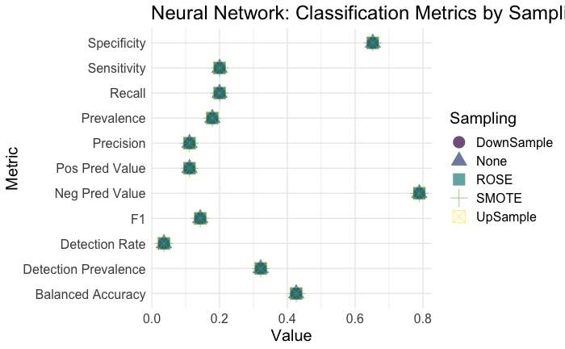

## Results

`r`r lapply(nnetPredictions, table)

```
$None
         obs
pred      Control Episode
  Control      23       5
  Episode       0       0

$DownSample
         obs
pred      Control Episode
  Control      18       3
  Episode       5       2

$UpSample
         obs
pred      Control Episode
  Control      21       3
  Episode       2       2

$SMOTE
         obs
pred      Control Episode
  Control      19       4
  Episode       4       1

$ROSE
         obs
pred      Control Episode
  Control      15       2
  Episode       8       3
```

`r`r do.call(rbind, nnetPredictions)%>% rownames_to_column()%>% rename(S = rowname)%>% separate(S, c(, ), sep = \.)%>% select(-xx)%>% group_by(Sampling)%>% summarise(Overall_Accuracy = sum(pred == obs)/n())%>% arrange(desc(Overall_Accuracy)) r final_nn = comparisons%>% filter(Sampling == )%>% arrange(Variable)%>% mutate(Model = )%>% select(Model, everything()) final_nn

| Sampling | Overall_Accuracy |
| --- | --- |
| None | 0.8214286 |
| UpSample | 0.8214286 |
| DownSample | 0.7142857 |
| SMOTE | 0.7142857 |
| ROSE | 0.6428571 |

| Model | Sampling | Variable | Value |
| --- | --- | --- | --- |
| NeuralNetwork | None | Balanced Accuracy | 0.42608696 |
| NeuralNetwork | None | Detection Prevalence | 0.32142857 |
| NeuralNetwork | None | Detection Rate | 0.03571429 |
| NeuralNetwork | None | F1 | 0.14285714 |
| NeuralNetwork | None | Neg Pred Value | 0.78947368 |
| NeuralNetwork | None | Pos Pred Value | 0.11111111 |
| NeuralNetwork | None | Precision | 0.11111111 |
| NeuralNetwork | None | Prevalence | 0.17857143 |
| NeuralNetwork | None | Recall | 0.20000000 |
| NeuralNetwork | None | Sensitivity | 0.20000000 |

[output cut: 1 more lines]

# Conclusion

This table ranks all of the best models for each metric:

`r`r rbind(final_glm, final_RF, final_svm, final_nn)%>% group_by(Variable)%>% arrange(Variable, desc(Value))

| Model | Sampling | Variable | Value |
| --- | --- | --- | --- |
| LogisticRegression | SMOTE | Balanced Accuracy | 0.64782609 |
| RandomForest | UpSample | Balanced Accuracy | 0.42608696 |
| SVM | None | Balanced Accuracy | 0.42608696 |
| NeuralNetwork | None | Balanced Accuracy | 0.42608696 |
| LogisticRegression | SMOTE | Detection Prevalence | 0.35714286 |
| RandomForest | UpSample | Detection Prevalence | 0.32142857 |
| SVM | None | Detection Prevalence | 0.32142857 |
| NeuralNetwork | None | Detection Prevalence | 0.32142857 |
| LogisticRegression | SMOTE | Detection Rate | 0.10714286 |
| RandomForest | UpSample | Detection Rate | 0.03571429 |

[output cut: 34 more lines]

The overall accuracy is 82% for logistic regression (the same), 78% for random forest (decreased), 82% for the SVM (decreased), and 82% for neural network (decreased)